# Word Prediction: Exploratory Analysis

## Data loading

Due to the size of the files, the downloading and unzipping of the data files is not included in this document. So I start with loading the data.

```r
library(dplyr)
library(tidytext)
library(ggplot2)

set.seed(42)

path <- './Coursera-SwiftKey/final/en_US/'

blogs <- 'en_US.blogs.txt'
news <- 'en_US.news.txt'
twitter <- 'en_US.twitter.txt'

if (!exists('linesBlogs')) {
  connection <- file(paste0(path, blogs), "rb")
  linesBlogs <- readLines(connection, encoding="utf-8")
  close(connection)
}

if (!exists('linesNews')) {
  connection <- file(paste0(path, news), "rb")
  linesNews <- readLines(connection, encoding="utf-8")
  #lines <- readLines(connection, 1)
  close(connection)
}

if (!exists('linesTwitter')) {
  connection <- file(paste0(path, twitter), "rb")
  linesTwitter <- readLines(connection, encoding="utf-8")
  #lines <- readLines(connection, 1)
  close(connection)
}
```

## Data preprocessing and cleaning

As the dataframes generated when calculating n-grams quickly become very large, I limit the exploratory analysis - as well as the latter modeling - to a subset of the data consisting of 20,000 entries from each of the three data sources.

```r
# sample for testing purposes
sampleBlogs <- linesBlogs[sample(length(linesBlogs), 20000)]
sampleNews <- linesNews[sample(length(linesNews), 20000)]
sampleTwitter <- linesTwitter[sample(length(linesTwitter), 20000)]

# combine into one dataframe
text_df <- rbind(data.frame(text = sampleBlogs), data.frame(text = sampleNews), data.frame(text = sampleTwitter))
text_df$text <- as.character(text_df$text)
```

There were some issues with data quality. Special characters including a number of punctuation marks were imported incorrectly. This was not so dramatic, as those were by and large eliminated or at least did not play a significant role in the analyis, except for quoation marks used e.g. in *it’s* or *you’re* which required some extra attention.

```r
# remove numbers as they do not seem really helpful for prediction and are not removed automatically at later stage when creating ngrams
text_df$text <- gsub('[0-9]+', '', text_df$text)

# replace 'Ã¢â¬â¢' and 'Ã¢â¬Å' with single and apostrophe as apostprophe is not properly read
text_df$text <- gsub('Ã¢â¬â¢', '\'', text_df$text)
text_df$text <- gsub('Ã¢â¬Å', '"', text_df$text)

# remove remaining 'Ã¢' and 'Ã'
text_df$text <- gsub('Ã¢â¬', '"', text_df$text)
text_df$text <- gsub('[Ã¢Ã]', '"', text_df$text)
```

## Exploratory data analysis

I then used this data to generate n-grams, starting with n = 1, i.e. just words. A plot of the most frequent words shows that prepositions, articles and simple verbs are most frequent.

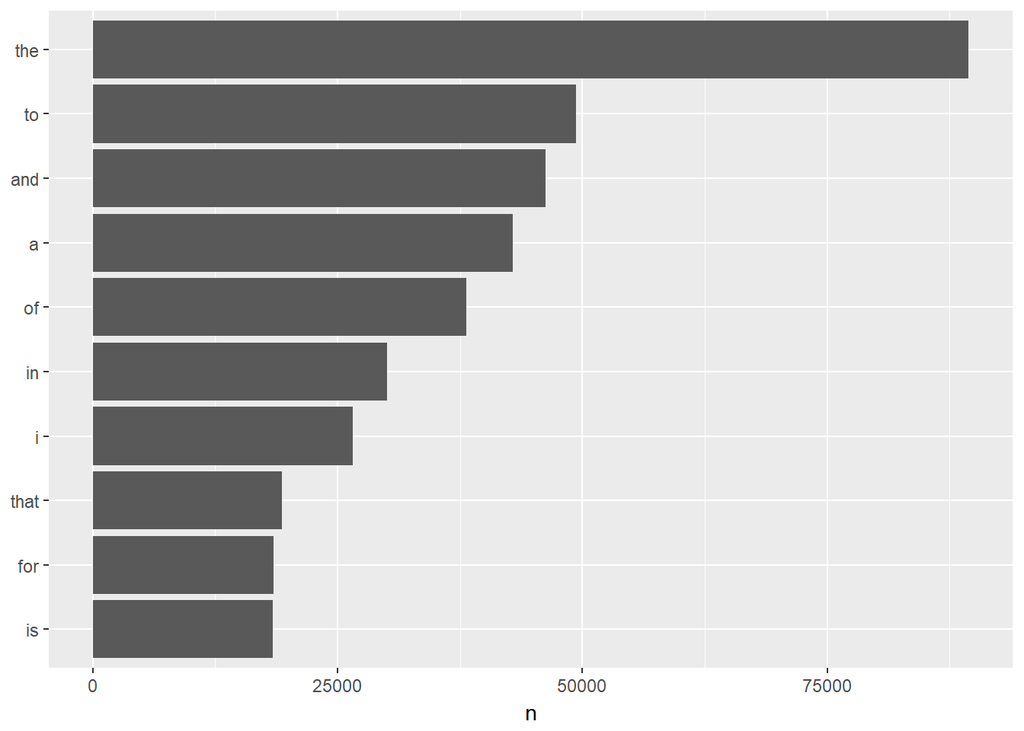

```r
# generate oneGrams
oneGram <- text_df %>% unnest_tokens(word, text)

# count oneGrams, select most popular 10 and display
oneGramTop10 <- oneGram %>% count(word, sort = TRUE) %>%
  top_n(10) %>% mutate(word = reorder(word, n))

# this is ordering without using dplyr
# oneGramTop10$word <- factor(oneGramTop10$word , levels = oneGramTop10$word [order(oneGramTop10$n)])
ggplot(aes(word, n), data = oneGramTop10) + geom_col() + xlab(NULL) + coord_flip()
```

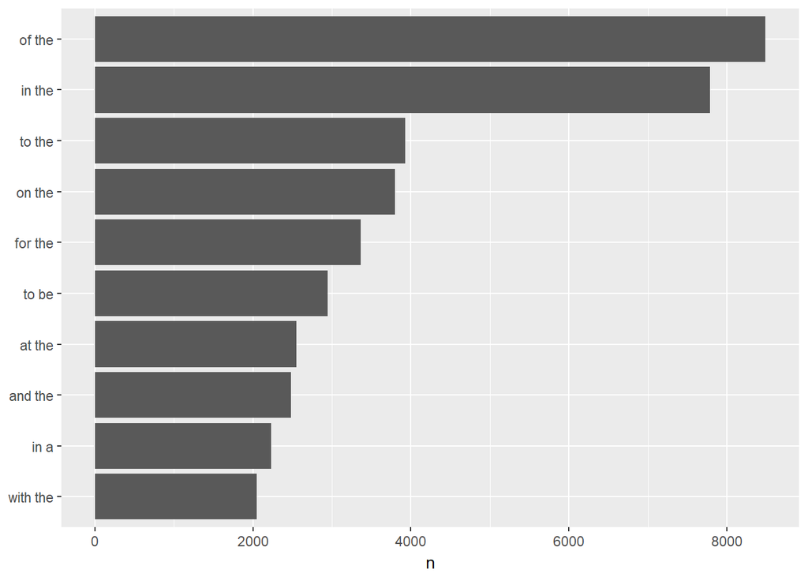

```r
# generate biGrams
biGram <- text_df %>% unnest_tokens(bigram, text, token = "ngrams", n = 2)

# count biGrams, select most popular 10 and display
biGram <- biGram %>% count(bigram, sort = TRUE) %>% mutate(bigram = reorder(bigram, n))
biGramTop10 <- biGram[1:10,]

ggplot(aes(bigram, n), data = biGramTop10) + geom_col() + xlab(NULL) + coord_flip()
```

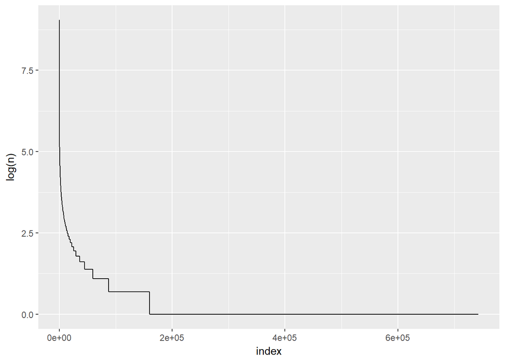

```r
# display density distribution of biGrams on log scale
biGram$index <- seq(1, dim(biGram)[1])
ggplot(aes(index, log(n)), data = biGram) + geom_line()
```

For 3-grams and 4-grams, I followed the same approach. The charts show the same pattern with even steeper declines in the log of the number of occurences as n increases.

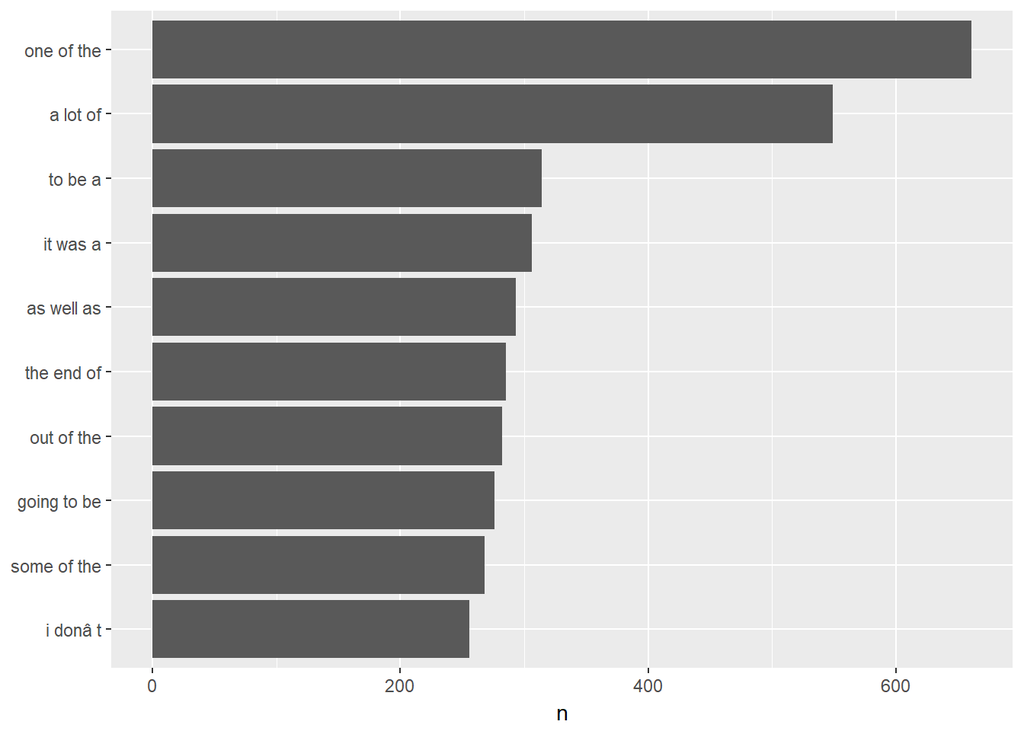

```r
# generate threeGrams
threeGram <- text_df %>% unnest_tokens(threegram, text, token = "ngrams", n = 3)

# count threeGrams, select most popular 10 and display
threeGram <- threeGram %>% count(threegram, sort = TRUE) %>% mutate(threegram = reorder(threegram, n))
threeGramTop10 <- threeGram[1:10,]

ggplot(aes(threegram, n), data = threeGramTop10) + geom_col() + xlab(NULL) + coord_flip()
```

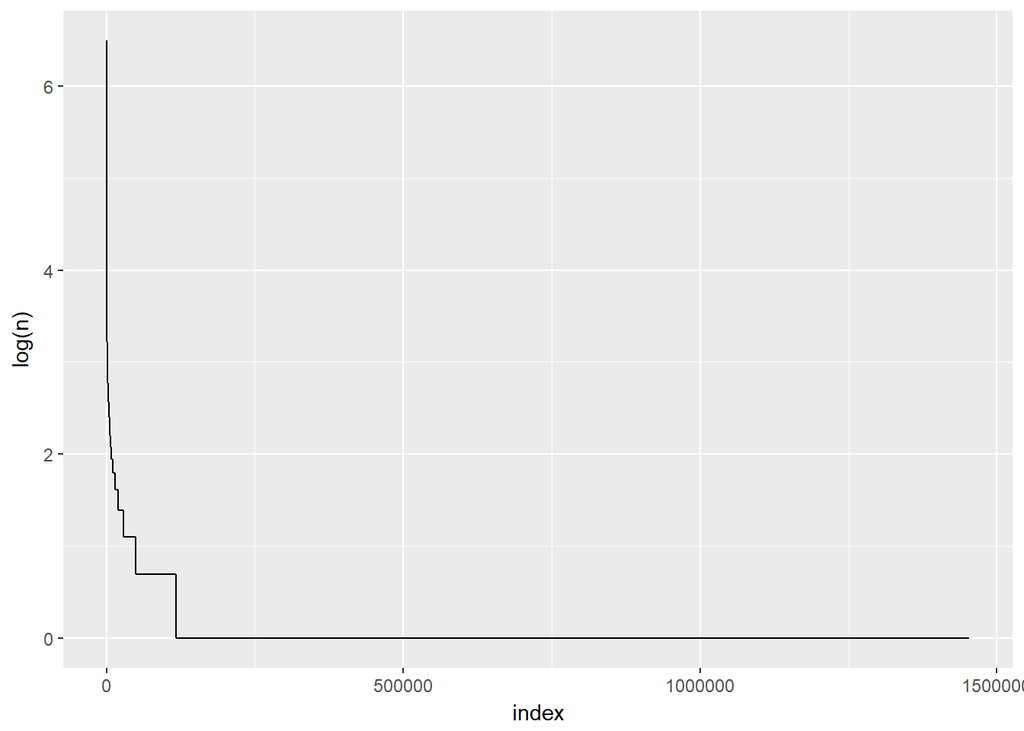

```r
# display density distribution of threeGrams on log scale
threeGram$index <- seq(1, dim(threeGram)[1])
ggplot(aes(index, log(n)), data = threeGram) + geom_line()
```